# RMarkdown introduction

Provides an unified authoring framework for data science, combining your code, its results, and your prose commentary. R Markdown documents are fully reproducible and support dozens of output formats, like PDFs, Word files, slideshows, and more.

In more details:

- https://r4ds.had.co.nz/r-markdown.html
- https://bookdown.org/yihui/rmarkdown-cookbook/

## Markdown language

Unordered list

- item 1
- item 2

Ordered list

1. first item
2. second item

**Bold**

*italic*

*bold italic*

Mathematical expressions:

$$\mu = \frac{\sum x_{i}}{N}$$

## Code Chunks

Surround code chunks with `` ```{r ...} `` and `` ``` ``. Add a chunk label and/or chunk options inside the curly braces after `r`. Use `` ` code ` `` to put inline code in the text.

### Chunk Options

Options control whether a chunk is executed and how its output is displayed.

#### no options

```r
head(wage1)
```

```
##   wage educ exper tenure nonwhite female married numdep smsa northcen south
## 1 3.10   11     2      0        0      1       0      2    1        0     0
## 2 3.24   12    22      2        0      1       1      3    1        0     0
## 3 3.00   11     2      0        0      0       0      2    0        0     0
## 4 6.00    8    44     28        0      0       1      0    1        0     0
## 5 5.30   12     7      2        0      0       1      1    0        0     0
## 6 8.75   16     9      8        0      0       1      0    1        0     0
##   west construc ndurman trcommpu trade services profserv profocc clerocc
## 1    1        0       0        0     0        0        0       0       0
## 2    1        0       0        0     0        1        0       0       0
## 3    1        0       0        0     1        0        0       0       0
## 4    1        0       0        0     0        0        0       0       1
## 5    1        0       0        0     0        0        0       0       0
## 6    1        0       0        0     0        0        1       1       0
##   servocc    lwage expersq tenursq
## 1       0 1.131402       4       0
## 2       1 1.175573     484       4
## 3       0 1.098612       4       0
## 4       0 1.791759    1936     784
## 5       0 1.667707      49       4
## 6       0 2.169054      81      64
```

#### `echo = FALSE`

```
##   wage educ exper tenure nonwhite female married numdep smsa northcen south
## 1 3.10   11     2      0        0      1       0      2    1        0     0
## 2 3.24   12    22      2        0      1       1      3    1        0     0
## 3 3.00   11     2      0        0      0       0      2    0        0     0
## 4 6.00    8    44     28        0      0       1      0    1        0     0
## 5 5.30   12     7      2        0      0       1      1    0        0     0
## 6 8.75   16     9      8        0      0       1      0    1        0     0
##   west construc ndurman trcommpu trade services profserv profocc clerocc
## 1    1        0       0        0     0        0        0       0       0
## 2    1        0       0        0     0        1        0       0       0
## 3    1        0       0        0     1        0        0       0       0
## 4    1        0       0        0     0        0        0       0       1
## 5    1        0       0        0     0        0        0       0       0
## 6    1        0       0        0     0        0        1       1       0
##   servocc    lwage expersq tenursq
## 1       0 1.131402       4       0
## 2       1 1.175573     484       4
## 3       0 1.098612       4       0
## 4       0 1.791759    1936     784
## 5       0 1.667707      49       4
## 6       0 2.169054      81      64
```

#### `eval = FALSE`

```r
head(wage1)
```

## Introduction

This is a report on Hotel prices in Vienna in 2017. You want to understand the connection between hotel prices and guest ratings.

## Data

We use a dataset containing hotel prices and features across 46 European cities for ten different dates. The data were cleaned and filtered to include only hotels in Vienna in 2017.

```
## Rows: 241
## Columns: 9
## $ starrating      <fct> 3, 3, 3, 3, 3, 3, 3, 3, 4, 3, 3, 3, 3, 3, 4, 3, 3, 3, …
## $ ratings         <dbl> 3.9, 3.5, 3.5, 3.2, 3.5, 3.2, 3.0, 3.9, 4.1, 3.4, 3.5,…
## $ hotel_id        <dbl> 22344, 22268, 21935, 22080, 22304, 22408, 21964, 22075…
## $ offer           <dbl> 1, 1, 1, 1, 1, 1, 1, 1, 1, 1, 1, 0, 1, 1, 1, 0, 1, 1, …
## $ offer_cat       <chr> "15-50% offer", "15-50% offer", "50%-75% offer", "15-5…
## $ holiday         <dbl> 0, 0, 0, 0, 0, 0, 0, 0, 0, 0, 0, 0, 0, 0, 0, 0, 0, 0, …
## $ nights          <dbl> 1, 1, 1, 1, 1, 1, 1, 1, 1, 1, 1, 1, 1, 1, 1, 1, 1, 1, …
## $ price_per_night <dbl> 50, 52, 54, 54, 56, 58, 59, 59, 60, 63, 63, 63, 66, 66…
## $ distance        <dbl> -3.9, -3.1, -2.0, -1.1, -3.7, -1.4, -13.0, -1.6, -1.1,…
```

```
## # A tibble: 6 × 9
##   starrating ratings hotel_id offer offer_cat     holiday nights price_per_night
##   <fct>        <dbl>    <dbl> <dbl> <chr>           <dbl>  <dbl>           <dbl>
## 1 3              3.9    22344     1 15-50% offer        0      1              50
## 2 3              3.5    22268     1 15-50% offer        0      1              52
## 3 3              3.5    21935     1 50%-75% offer       0      1              54
## 4 3              3.2    22080     1 15-50% offer        0      1              54
## 5 3              3.5    22304     1 15-50% offer        0      1              56
## 6 3              3.2    22408     1 15-50% offer        0      1              58
## # ℹ 1 more variable: distance <dbl>
```

## Descriptives

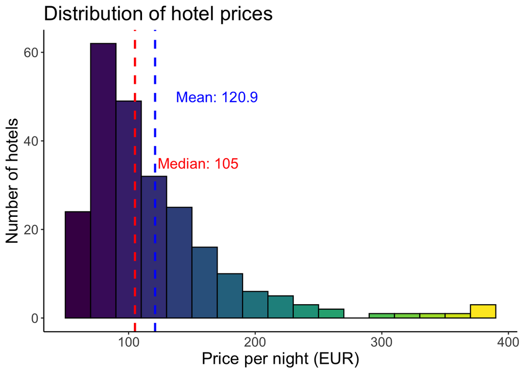

What’s the connection between hotel prices and ratings?

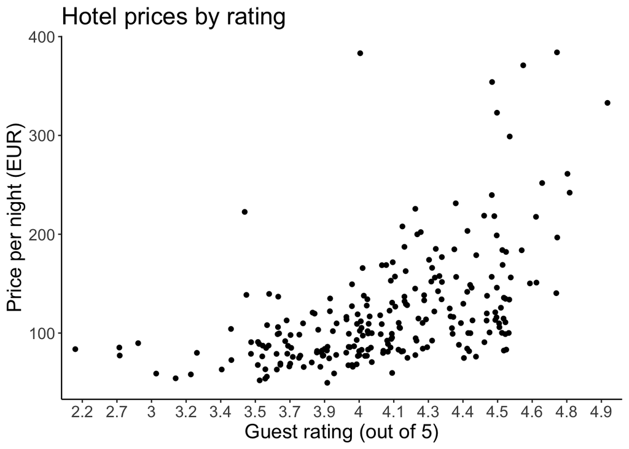

What’s the connection between hotel prices and stars?

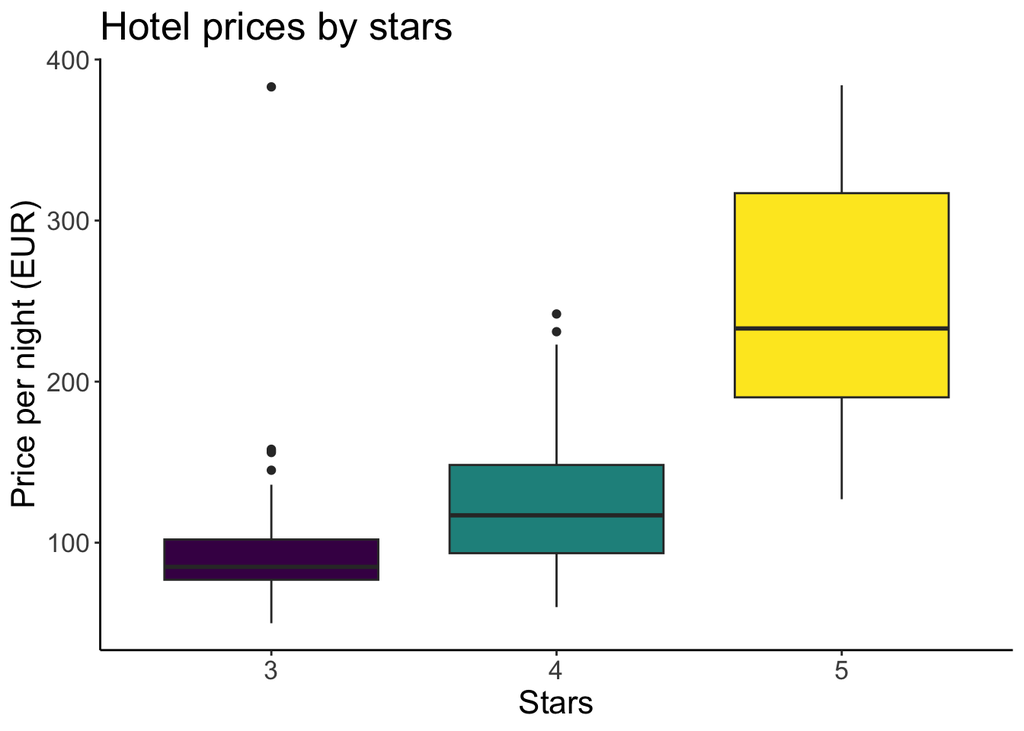

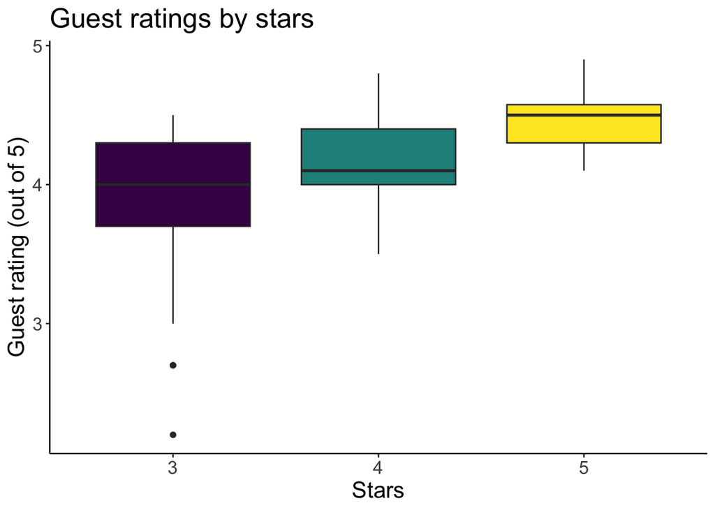

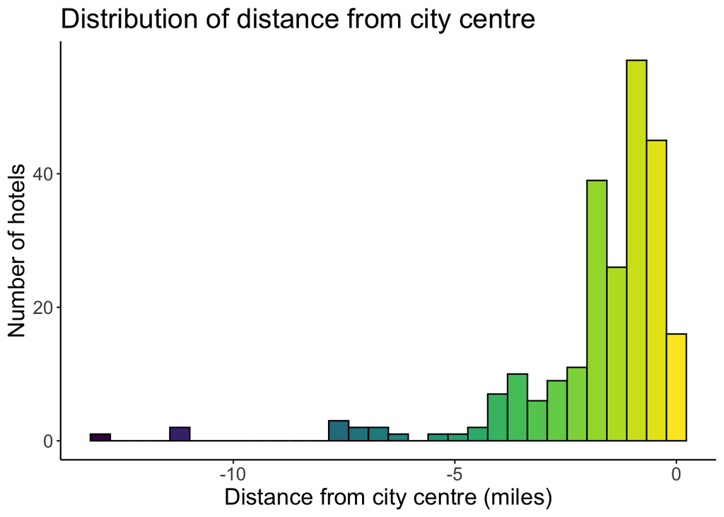

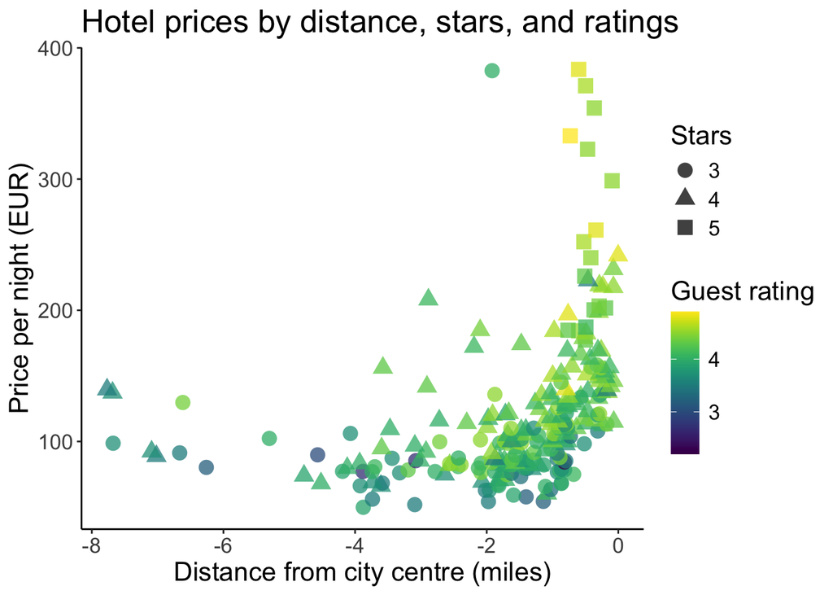

## Regression

Run the following regression:

$$ln(Price_{i}) = \beta_{0} + \beta_{1} ratings_{i} + \beta_{2} stars_{i}
+ \beta_{3} distance_{i} + \varepsilon_{i}$$

```
##
## Regression results
## ========================================================
##                               Dependent variable:
##                         --------------------------------
##                           Log of price per night (EUR)
##                             (1)        (2)        (3)
## --------------------------------------------------------
## Guest rating (out of 5)  0.562***    0.367***  0.336***
##                           (0.054)    (0.048)    (0.050)
## 4 stars                              0.205***  0.201***
##                                      (0.038)    (0.038)
## 5 stars                              0.793***  0.774***
##                                      (0.074)    (0.074)
## Distance (miles)                                0.021**
##                                                 (0.010)
## Constant                 2.417***    3.051***  3.218***
##                           (0.220)    (0.191)    (0.205)
## --------------------------------------------------------
## Observations                241        241        241
## R2                         0.314      0.540      0.548
## Adjusted R2                0.311      0.534      0.541
## ========================================================
## Note:                        *p<0.1; **p<0.05; ***p<0.01
##                           Standard errors in parentheses
```